# Ford GoBike System Data

## *by Chisom Maduka*

## Investigation Overview

Ford GoBike is a regional public bicycle sharing system covering the greater part of San Francisco Bay area, and represents the first regional and large-scale bicycle sharing system deployed in California and on the West Coast of the United States.

In this project, data visulization will be performed by using univariate, bivariate, and multivariate plots to explore and gather more information about individual Ford GoBike user behaviours and preferences by studying trends, changes and differences in the month of February 2019.

## Dataset Overview

I extracted the Ford GoBike dataset for February, 2019 containing the following parameters: Trip Duration (seconds), Start Time, End Time, Start Station ID, Start Station Name, Start Station Latitude, Start Station Longitude, End Station ID, End Station Name, End Station Latitude, End Station Longitude, Bike ID, User Type (Subscriber or Customer), Member Birth Year, Member Gender and Bike Share for all Trip.

After series of data assessment, basic data cleaning was performed to produce an error free data needed for analysis. This included dropping redundant columns and creating new ones from some old columns, as well as changing their datatypes. Out of the 183412 original entries, there was 174760 entries left, and the resulting features which I focused on during investigation was:

- duration_sec
- start_station_name
- bike_id
- user_type
- member_gender
- age
- start_hour
- duration_min
- duration_hour
- day_of_week
- week_type

## Visualization 1: Statistical Distribution of User Types

There were 90.5% Subscribers and just 9.5% Customers, which accounts for over 150,000 Subscribers as displayed in the chart below.

Note: **Subscribers** are people that are registered members in the biking system, which makes them entitled to any benefits including discounts.

**Customers** on the other hand may also be referred to as visitors, and are not registered members.

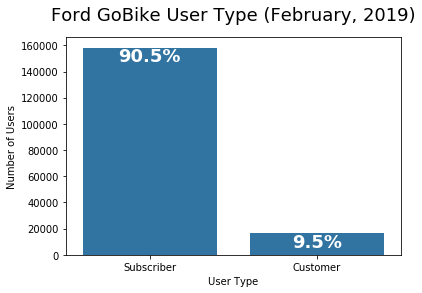

## Visualization 2: Ford GoBike Biking System Trends by User Type

On the average we can see that for **subscribers**, users seem to be more active on weekdays (Monday to Friday) than weekends (Saturday and Sunday), with Thursdays topping the list with over 30,000 users. The least recorded was on weekends, and results showed a drastic drop to as low as about 12,000 users each both on saturday and sunday. This can be explained by the busy and work practices that propels many to consistently bike to various locations either at the same or different time from Mondays all through Fridays. But on Saturdays and Sundays, quite a number of users probably rest or reduce their movements, resulting in lower out turn.

However, there is a consistent and significant drop in the number of trips taken by **customers** and this spreaded quite evenly in each day of week, with little or no difference in trips taken. Less than 3,000 trips was recorded across all days, and it can be concluded that many of them are just visitors that probably are not local residents.

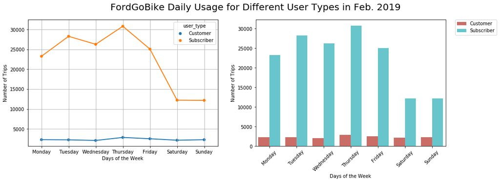

## Visualization 3: The daily trend in visits between customers and subscribers

The trend in subscriber trips remained significantly high everyday of the week, as many users were recorded to have travelled during peak hours between 7-9am (with over 40,000 trips) and 4-6pm (with over 45,000 trips). This may be explained by the period when people go to work and at the time of return back home. The trend spreaded quite evenly between 10am and 3pm, which indicated working period for many and so, not as much commuters were recorded.

But for customer users, their number of trips was low allthrough the week.

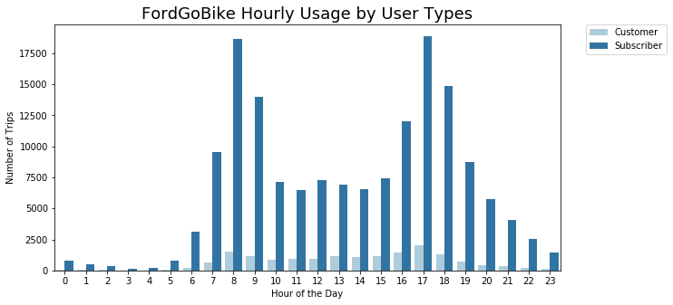

## Visualization 4: Who do we consider the target audience that drives sales the most?

In conclusion, young adults (between 18-40 years) accounting for 0ver 70% of the population are considered the target market since statistics showed that they travelled more often and at longer time, which signifies more revenue generated.

young_adults: age 18-40 years

older_adults: age 40-70 years

seniors: age 70-80 years

```
Text(0,0.5,'Duration in minutes')
```

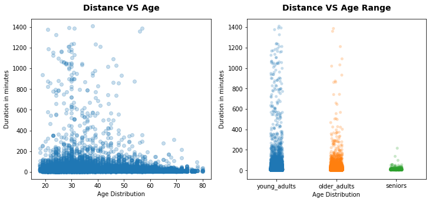